# What It Takes

to Play NCAA College Basketball

Gary William Christian Curkan and Son Luong

12/06/2021

# Introduction and Exploring Data

Statistics are a good way to tell how you are doing in a sport and what you are best at. They can also help to determine where you and your team need to improve. We work on the College Basketball created by Aditya Kumar from Kaggle, which contains past decade’s NCAA college basketball data.

Our goal was to look at data trends based on role categorized into Post Players (PowerForward Center, Center, Wing Forward, Stretch 4) and Guards (Combo Guard, Scoring Point Guard, Wing Guard, Pure Point Guard); and academic status (freshman, sophomores, juniors, and seniors).

At first… Cleaned data to make easier to work with:

- rename variables to readable, workable names
- remove less-meaningful variables

Later…

- Filter to past 3 seasons to look at newer data
- Create a few new variables for working the data

# Fun Fax

- How many teams are represented in this dataset

```
##   all_years
## 1       362
```

```
##   x2018up
## 1     358
```

- How many unique players in NCAA 2018+

```
##   all_years
## 1     24073
```

```
##   x2018up
## 1    8697
```

- How many recurring players from seasons 2018-19+

```
## # A tibble: 1 × 1
##   recurring_players
##               <int>
## 1                11
```

How’s relationship between all the varibles?

First, we take a look at how’s relationship between all the varibles?

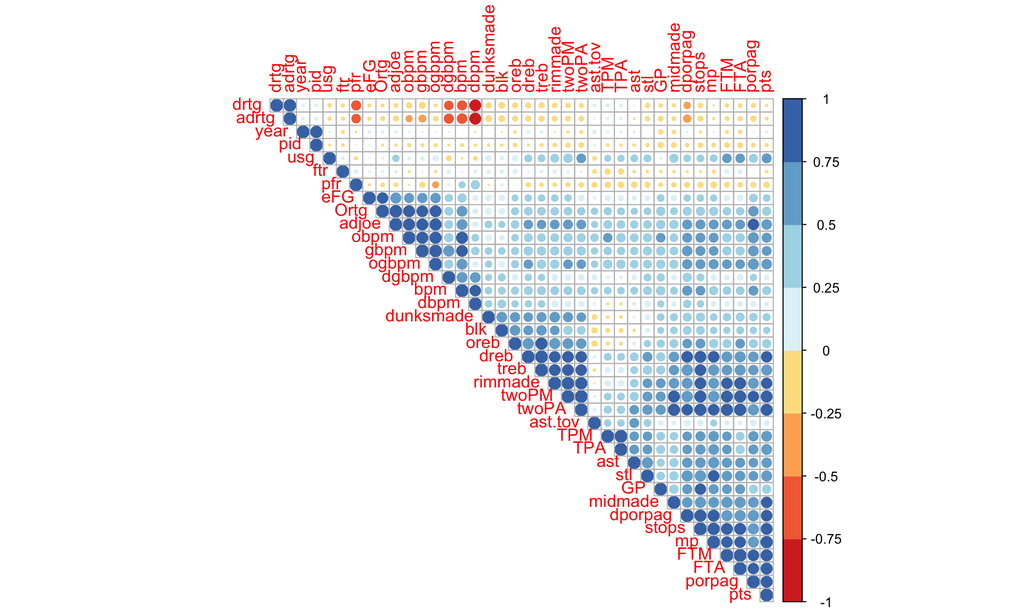

# Visualization

Sports require teamwork! For how to evaluate a good team player, we measure player’s contributions and their impact on the court by BPM (Box Plus/Minus). The more time they contribute on the court, the more points they get.

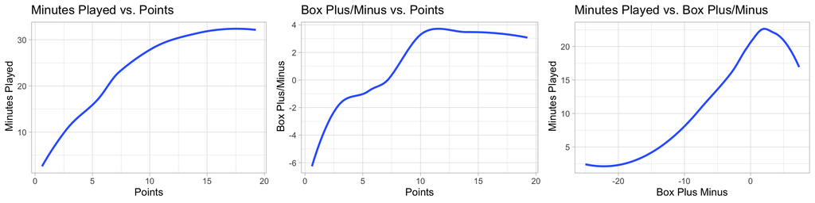

How Each Position Attributes into Gaining Points

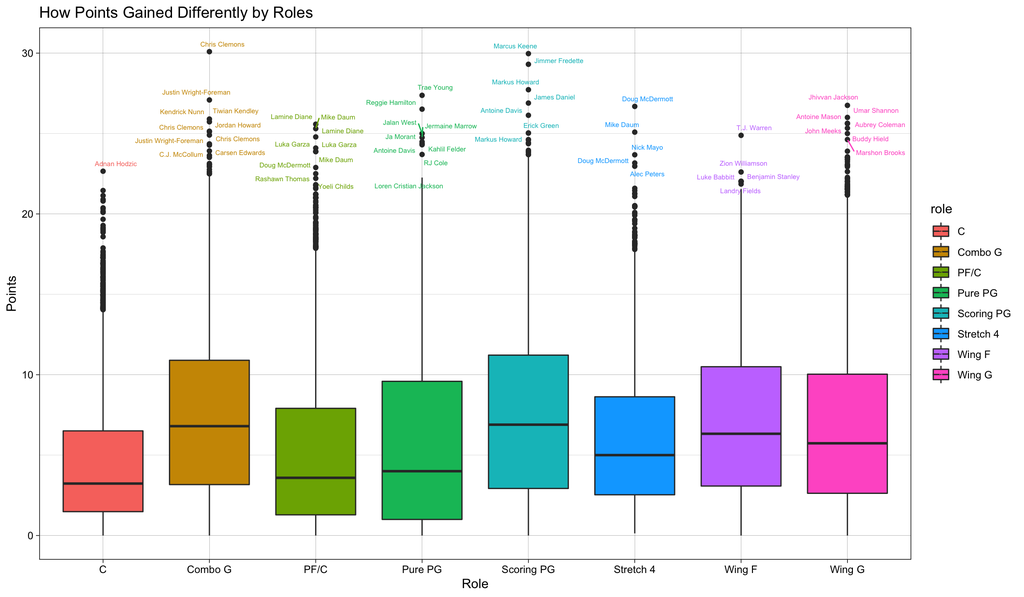

How academic status (freshman, sophmores, juniors, and seniors) affect their performance?

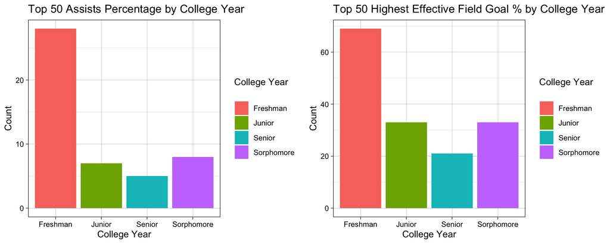

The relationship between Game played and Effective Field Goal? The Powerforward Position seems like experience is very important to consider.

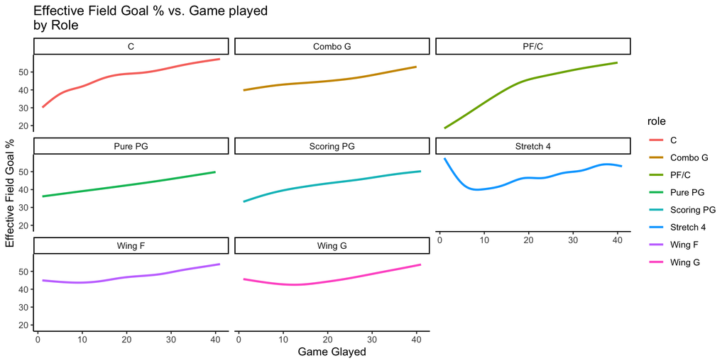

# Free Throws

Now we categorize all guard variations as guards, and all the Powerforwards, centers and stretch as post players.

Free Throws are incredibly important because they are uncontested shots

```
##   25%   50%   75%
## 0.500 0.667 0.769
```

```
## 25% 50% 75%
##   5  25  58
```

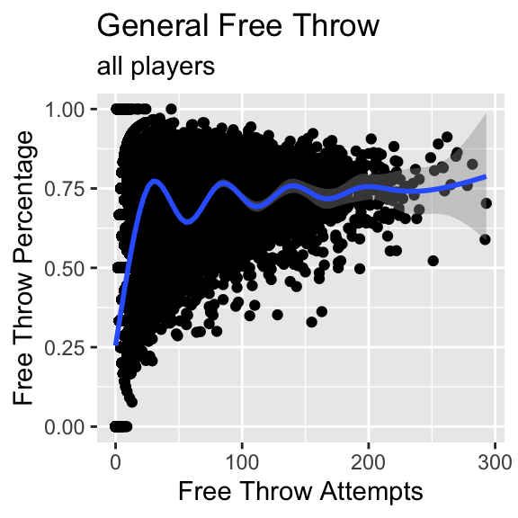

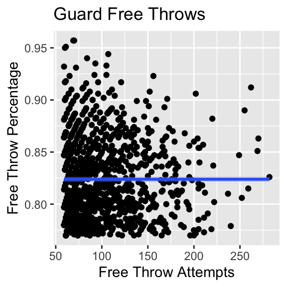

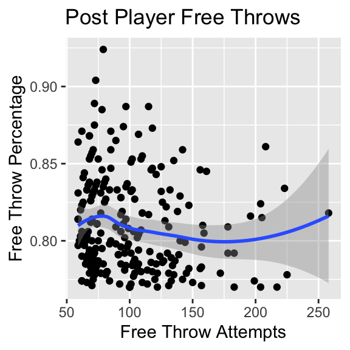

```
##            player           team       role TP_per
## 1 Deishuan Booker Long Beach St. Scoring PG  0.363
```

# Rebounds

Rebounds are important because this is where the teams show who wnats it more, this is where the game get’s physical, and personal.

```
##            player           team yr year
## 1      Jade Smith     Pepperdine So 2019
## 2    Chris Clarke     Texas Tech Sr 2020
## 3 Quinton Forrest          Idaho Jr 2020
## 4   Unique McLean St. Francis NY Sr 2020
## 5  Jordan Goodwin    Saint Louis Jr 2020
## 6   Radshad Davis   UT Arlington Sr 2020
## 7  Tyrece Radford  Virginia Tech Fr 2020
## 8  Garrett Sturtz          Drake So 2020
```

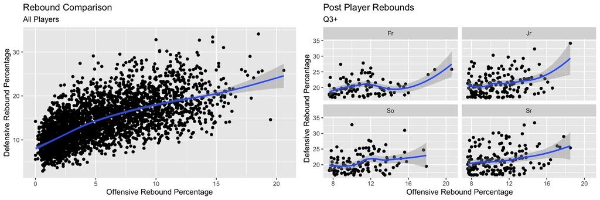

# Assists

Last but not least. Sport is all about teamwork. So, Assists are super important!

Let’s look at The Relationship between Point vs Assists by Team, and Top 10 teams have highest accumulated Assists.

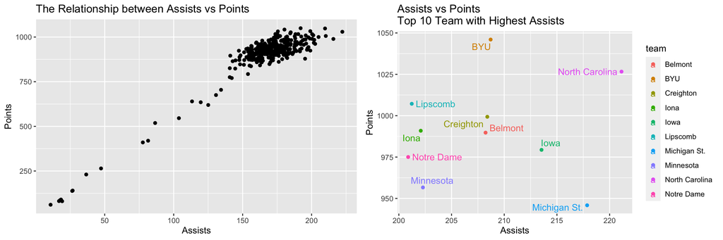

We filter down to the past 3 season’s top 25 teams.

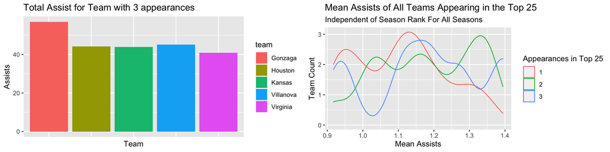

```
## # A tibble: 3 × 4
##   team     rank  year appearances
##   <chr>   <dbl> <dbl>       <int>
## 1 Duke        1  2019           2
## 2 Kansas      1  2020           3
## 3 Gonzaga     1  2021           3
```

# The assist to turnover ratio

The assist to turnover ratio is one of many basketball statistics used to evaluate the ball control and ball handling skills of a player

[figure not shown]

# Conclusion

Get Buckets

- Teams with high amounts of assists are getting high amounts of points.
- Competitive players shoot free throws with around 75% accuracy.
- The guy with the highest free throw accuracy kinda sucks.
- Most people getting rebounds are post players
- Made discoveries on how assists, while important do not necessarily prove a team’s skill

# References

Source of some questions:

https://www.breakthroughbasketball.com/stats/how-we-use-stats-Hagness.html

Data source:

https://www.kaggle.com/adityak2003/college-basketball-players-20092021/metadata